# Kira’s Regression

Kira Webster

2020-01-26

Starting with the iris data like usual, let’s make sure our dataset is active. Then we can get and reset the names of our iris columns with easier names.

```r
iris    #making sure Iris dataset is active
```

```
##     sepalL sepalW petalL petalW    species
## 1      5.1    3.5    1.4    0.2     setosa
## 2      4.9    3.0    1.4    0.2     setosa
## 3      4.7    3.2    1.3    0.2     setosa
## 4      4.6    3.1    1.5    0.2     setosa
## 5      5.0    3.6    1.4    0.2     setosa
## 6      5.4    3.9    1.7    0.4     setosa
## 7      4.6    3.4    1.4    0.3     setosa
## 8      5.0    3.4    1.5    0.2     setosa
## 9      4.4    2.9    1.4    0.2     setosa
## 10     4.9    3.1    1.5    0.1     setosa
## 11     5.4    3.7    1.5    0.2     setosa
## 12     4.8    3.4    1.6    0.2     setosa
## 13     4.8    3.0    1.4    0.1     setosa
## 14     4.3    3.0    1.1    0.1     setosa
```

[output cut: 136 more lines]

```r
names(iris) #checking Iris names so you can rename them
```

```
## [1] "sepalL"  "sepalW"  "petalL"  "petalW"  "species"
```

```r
names(iris) <- c("sepalL", "sepalW",  "petalL", "petalW", "species")    #Renaming iris with more convenient names
```

Now we define our variables, species, x, and y.

```r
species <- iris$species   #saving specific values from the Iris dataset as variables to use later
x <- iris$petalL
y <- iris$petalW
```

Now we set our intercept and slope to form our linear equation. Now that we have our equation we can plot our x and y plot, and create a line of best fit.

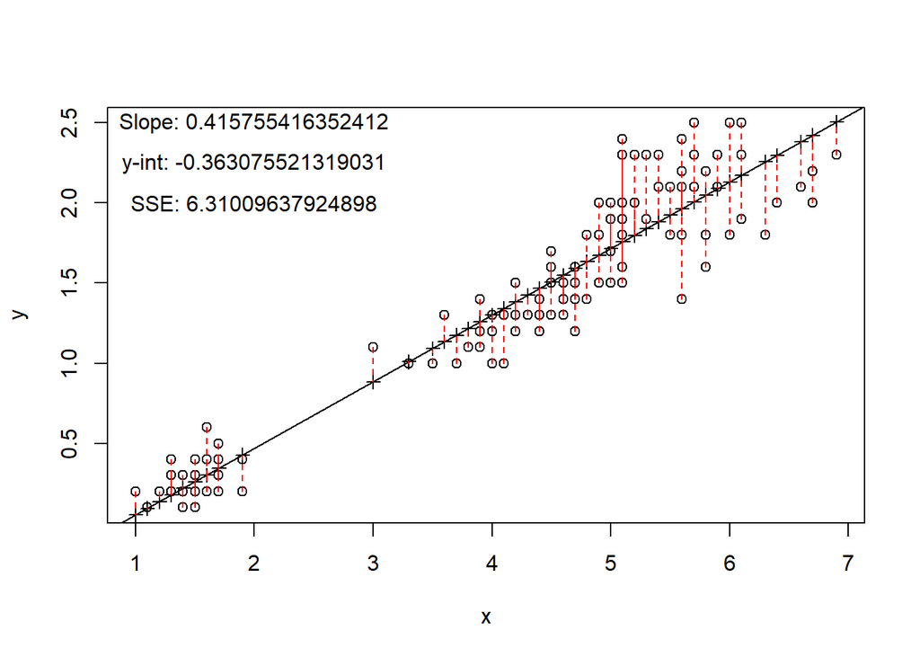

```r
fit <- lm( y ~ x )      #creating variable fit for the linear model
b <- coef( fit )     #naming b as the coefficient for the model
int <- b[1]     #redelegating b as the intercept, such as in y=mx+b
slope <- b[2]   #naming slope for the linear model

plot(x, y)      #now we can plot our previously named x as petal length and y as petal width
abline(fit)     #abline creates a line of best fit on the plot given the slope and intercept already laid out

yhat <- slope*x + int    #labeling the linear formula y=mx+b as yhat because y is already taken

points( x, yhat, pch=3)  #making the points that fall on the line of best fit obvious

i=150       #we now want to show the error margin between the points on contrasting sides of the line of best fit
segments( x[i], y[i], x[i], yhat[i], col="red" )    #we name segments as the connection between these points
segments( x, y, x, yhat, col="red", lty=2 )     #we formulate the segments and now they will appear

error <- (yhat-y)       #to calculate error between the points
sse <- sum(error^2)     #to calculate the sum of squared errors

text(2,2.5, paste("Slope:", slope))     #to add the text for slope to the graph
text(2,2.25, paste("y-int:", int))      #to add the text for y-intercept to the graph
text(2,2, paste("SSE:", sse))           #to add the text for SSE to the graph
```

# Function Wrap

This is my function wrap for the same function above. I have followed the order as above, but before the function begins you are allowed to define your variables so the function can run with any intercept and slope. After the function, but still in this chunk of text, are examples of intercepts and slopes I tested with this function.

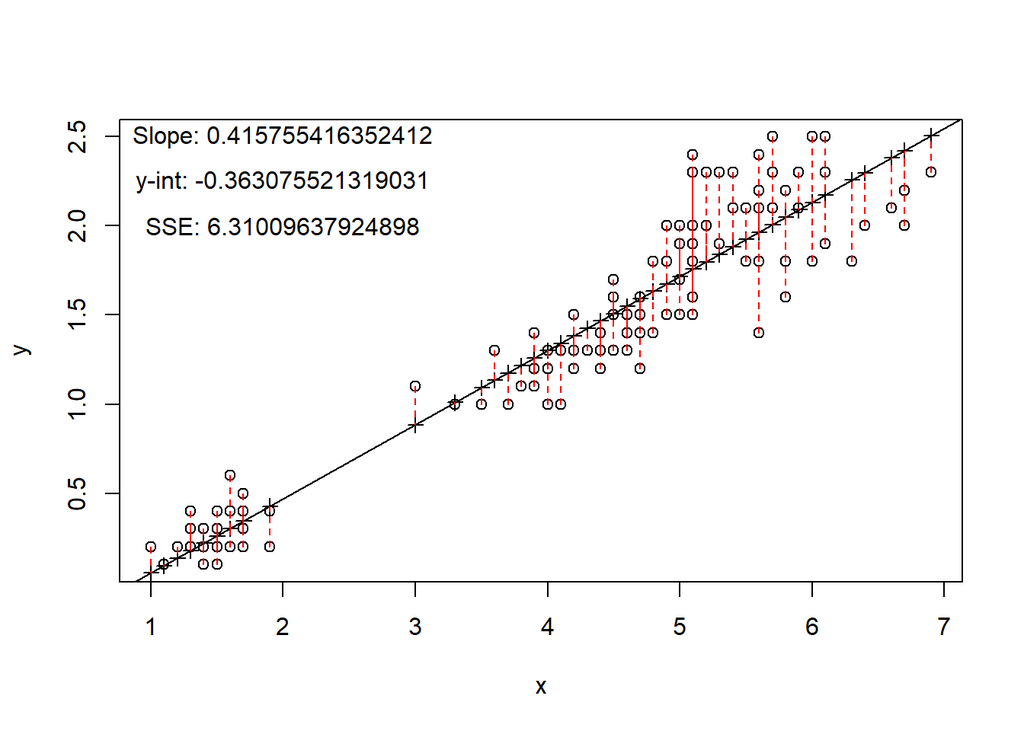

```r
myplot <- function(x=iris$petalL, y=iris$petalW, myint=int, myslope=slope)  {
    yhat <- myslope*x + myint
    error <- yhat - y
    sse <- sum(error^2)
    plot(x, y)
    abline(myint, myslope)
    points(x, yhat, pch=3)
    segments(x, y, x, yhat, col="red", lty=2)
    text(2,2.5, paste("Slope:", myslope))
    text(2,2.25, paste("y-int:", myint))
    text(2,2, paste("SSE:", sse))
}

myplot()
```

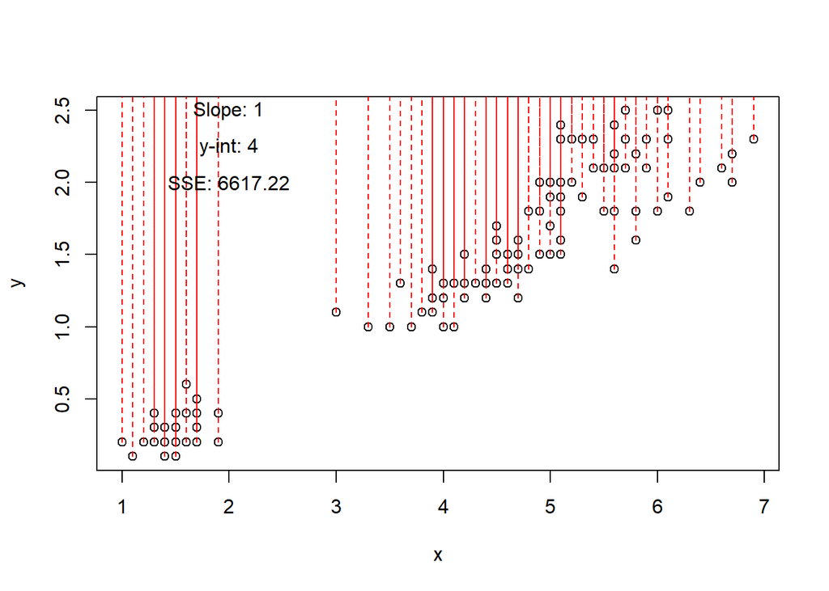

```r
myplot(myint=4, myslope=1)
```

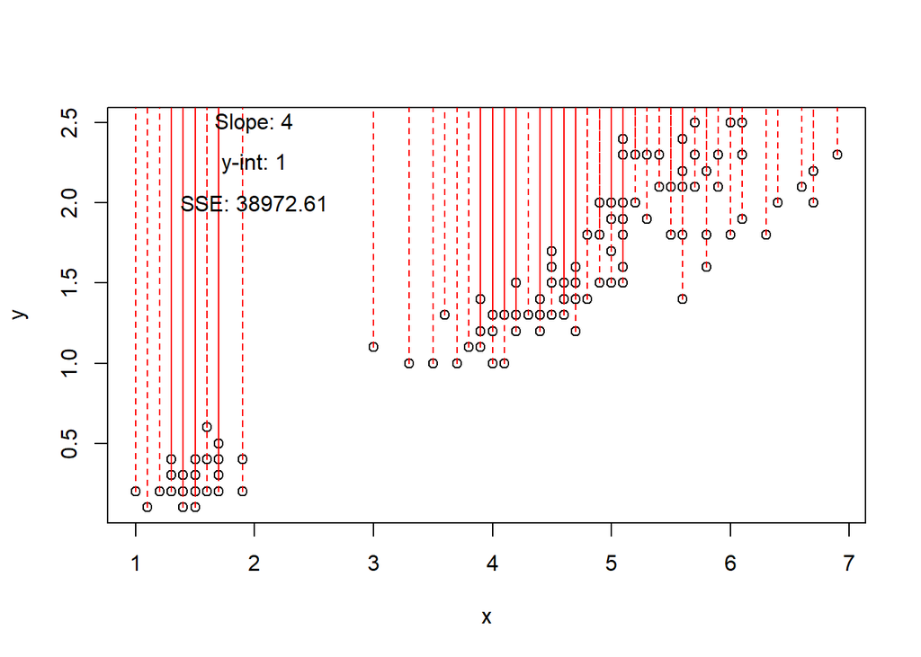

```r
myplot(myint=1, myslope=4)
```

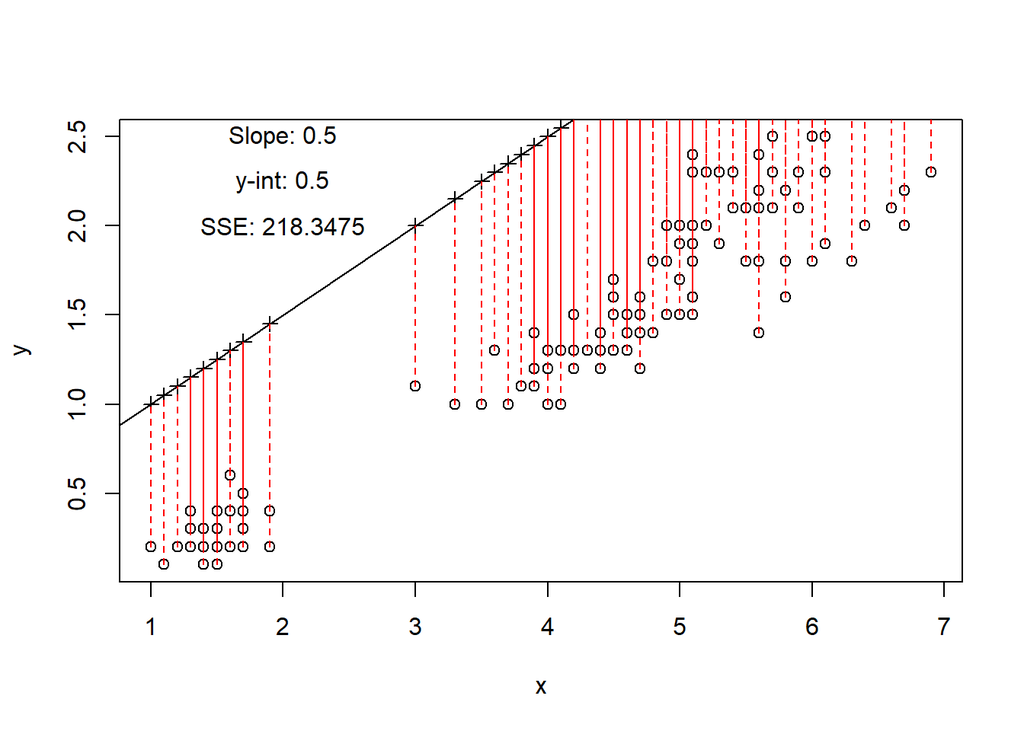

```r
myplot(myint=0.5, myslope=0.5)
```

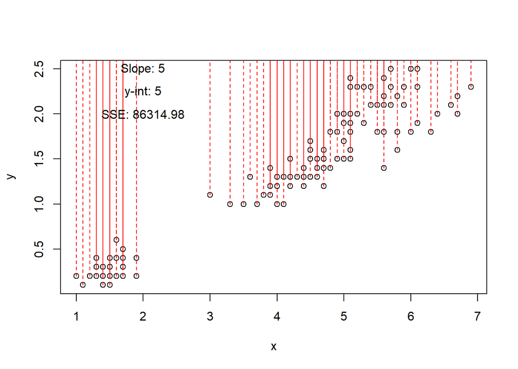

```r
myplot(myint=5, myslope=5)
```

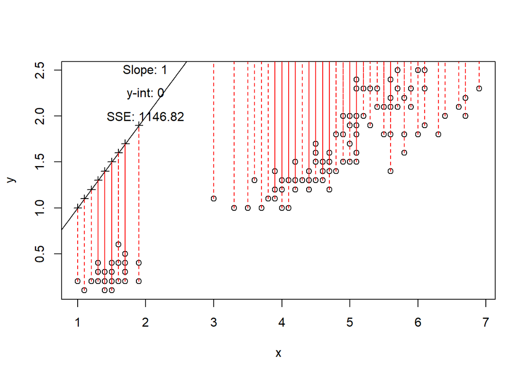

```r
myplot(myint=0, myslope=1)
```

# My Function

The function I have created allows you to convert both x and y by seperate conversion factors that you set yourself. I have used our old friend, the dataset cars, and taken the two variables it gives, speed and distance, for x and y. I looked up the units for these variables and they are mph and feet, respectively. By setting both conversion factors I end up with a graph in kph by meters. I added a line of best fit to better visualize the data.

```r
conversionfunction <- function(x=cars$speed, y=cars$dist, conv1=1.60934, conv2=0.3048)  {
    x <- x*conv1
    y <- y*conv2
    plot(x, y)
    fit <- lm (y~x)
    abline(fit)
}
```

These are examples of other datasets and variables I have selected to test this function with.

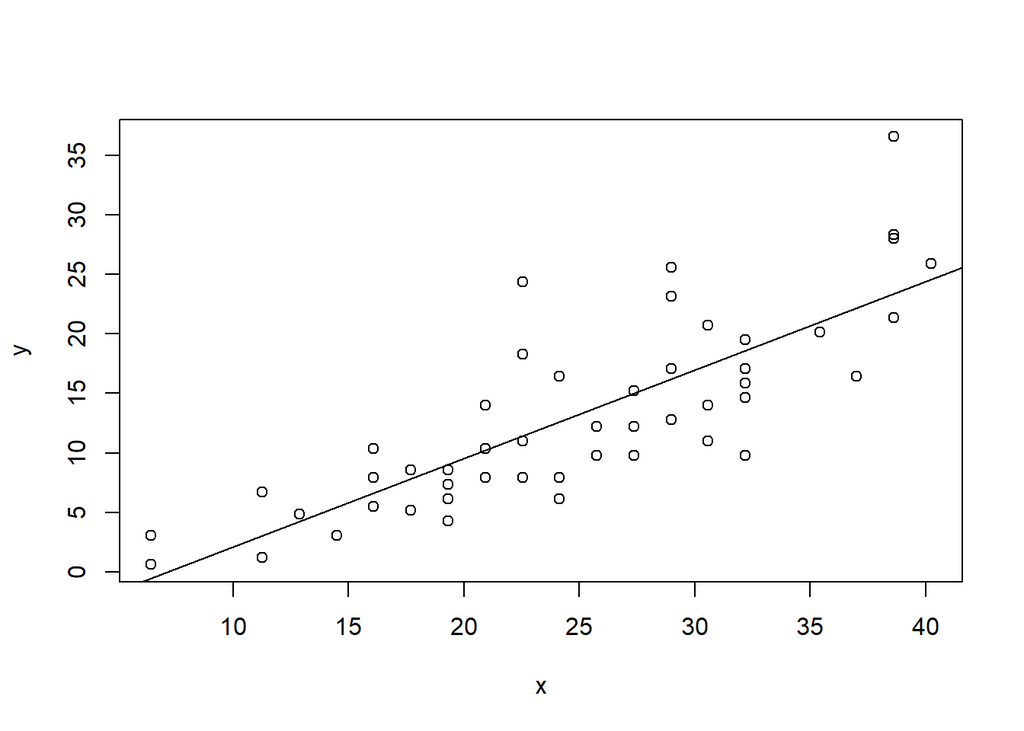

```r
conversionfunction()        #testing function with cars data, this converts speed from miles to kilometers, and distance from feet to meters.
```

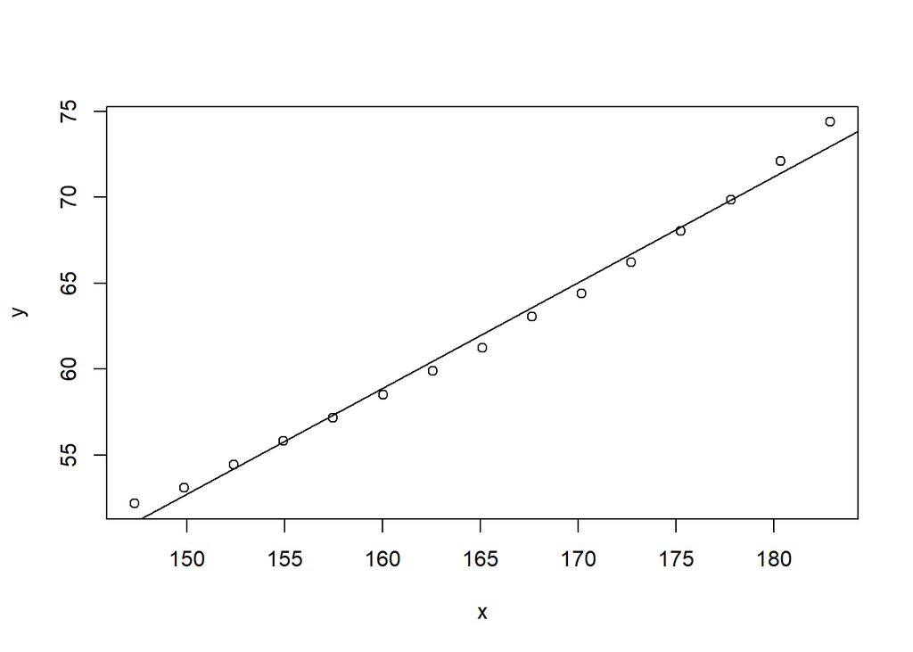

```r
conversionfunction(x=women$height, y=women$weight, conv1=2.54, conv2=0.4536)     #using the dataset women, this converts height from inches to centimeters, and weight from pounds to kilograms
```

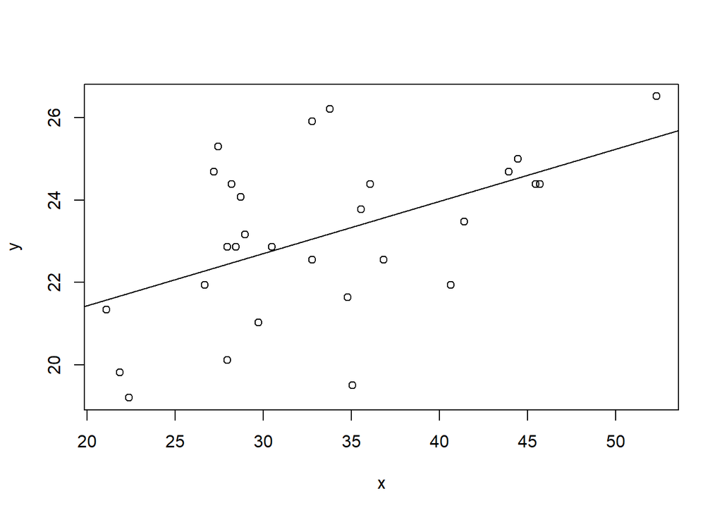

```r
conversionfunction(x=trees$Girth, y=trees$Height, conv1=2.54, conv2=0.3048)     #using the dataset trees, this converts tree girth from inches to centimeters, and tree height from feet to meters.
```